# EXPLORATION OF SALES AND FINANCE FOR THE FISCAL YEAR JANUARY, 2019 TO JANUARY, 2020

# 31st January, 2020

# A REPORT PRESENTED TO THE FINANCIAL TEAM AND MARKETING MANAGEMENT ON SALES TRENDS AND SALES RETURNS FOR THE FISCAL YEAR’S FINANCIAL SALES STATEMENT.

# 1 Introduction

This Report explores the possibility of using Python Programming as tools to automatically process data gathered from financial activities and extract relevant information to achieve the goals of the Marketing and Finance Team. The objective is to perform an automatic process of data using artificial intelligence techniques, in particular the application of machine learning algorithms. The final goal is to manage the extraction of quantitative data with relevant information to inform manager about the current competitiveness of our products and services.

## 1.1 Staement Of the Report

This report is intended to inform managment on the performance of the Marketing managers on how their marketing strategies were able to reach both loyal and impulse customers and improved Sales Value. This finance report will communicates the Firm's crucial financial information and competitiveness and covers a specified period through daily, weekly, and monthly financial reports. This will be our tools that you can apply to increase internal business performance as compared to privious years. The data on the finance report is also an effective means of remaining updated with any significant progress and changes in the status of our finances and guid as to measure our financial results, cash flow, and financial position on Monetary terms.

# 1.2 Objectives Of The Report

```
-- To Understand our current customer base in all States
-- To understand our Financial Position on how much Sales was declared
-- To Understand Buying trends base on Location and Day of The Week
-- To understand with of the Month or Day of the Week is suitable for promotion
-- To understand how many items were sold through out various Days of the Week and Months.
-- To understand most items sold and how much sales was made from each item sold in the Fiscal year.
```

```python
%%htmlfrom IPython.core.display import display, HTML
from IPython.display import display
from IPython.display import IFrame
```

```python
%%html%%javascript
IPython.notebook.save_notebook()
```

## 2.0 Data Preprocessing

###### Importing Important Python Libraries

```python
importitertoolsimportseabornassnsimportnumpyasnpimportmatplotlib.pyplotaspltimportseabornassnsfrommatplotlib.tickerimportNullFormatterimportpandasaspdimportnumpyasnpimportmatplotlib.tickerastickerfromsklearnimportpreprocessing%matplotlib inline
```

```python
importplotly.graph_objectsasgofromkaleido.scopes.plotlyimportPlotlyScopeimportplotly.graph_objectsasgo#import orcafrommatplotlib.tickerimportFuncFormatterfromscipy.statsimportnormimportseabornassnsimportplotly.expressaspxfromdatetimeimportdatetime,datetoday_date=date.today()importpandasaspdimportos
```

```python
fromplotly.offlineimportdownload_plotlyjs,init_notebook_mode,iplotinit_notebook_mode(connected=True)
```

### Loading Data Into Pandas DataFrame

```python
### Now We read from Updated Data stockData1=pd.read_csv("stockclosedata2.csv",na_values=[" ?"])stockData1.head()
```

|  | Order ID | Product | Quantity Ordered | Price Each | Order Date | Purchase Address |
| --- | --- | --- | --- | --- | --- | --- |
| 0 | 176558.0 | USB-C Charging Cable | 2.0 | 11.95 | 4/19/2019 8:46 | 917 1st St, Dallas, TX 75001 |
| 1 | NaN | NaN | NaN | NaN | NaN | NaN |
| 2 | 176559.0 | Bose SoundSport Headphones | 1.0 | 99.99 | 4/7/2019 22:30 | 682 Chestnut St, Boston, MA 02215 |
| 3 | 176560.0 | Google Phone | 1.0 | 600.00 | 4/12/2019 14:38 | 669 Spruce St, Los Angeles, CA 90001 |
| 4 | 176560.0 | Wired Headphones | 1.0 | 11.99 | 4/12/2019 14:38 | 669 Spruce St, Los Angeles, CA 90001 |

We call our Data Frame to print out our data in our Database or in our repositry and print the first five (5) rows of our Data frame.

```python
stockData1.isnull()
```

|  | Order ID | Product | Quantity Ordered | Price Each | Order Date | Purchase Address |
| --- | --- | --- | --- | --- | --- | --- |
| 0 | False | False | False | False | False | False |
| 1 | True | True | True | True | True | True |
| 2 | False | False | False | False | False | False |
| 3 | False | False | False | False | False | False |
| 4 | False | False | False | False | False | False |
| ... | ... | ... | ... | ... | ... | ... |
| 186845 | False | False | False | False | False | False |
| 186846 | False | False | False | False | False | False |
| 186847 | False | False | False | False | False | False |
| 186848 | False | False | False | False | False | False |
| 186849 | False | False | False | False | False | False |

186850 rows × 6 columns

We check in our data set if there are unusual entries in the data set, if there are any, python will automatically compute all our unusual entries and tell us which of our columns and rows contains these errors or entries. Where in the table indicates True means an error entry and where False means vice versa.

```python
(stockData1.info())
```

```
RangeIndex: 186850 entries, 0 to 186849
Data columns (total 6 columns):
# Column Non-Null Count Dtype
--- ------ -------------- -----
0 Order ID 185950 non-null float64
1 Product 185950 non-null object
2 Quantity Ordered 185950 non-null float64
3 Price Each 185950 non-null float64
4 Order Date 185950 non-null object
5 Purchase Address 185950 non-null object
dtypes: float64(3),object(3)
memory usage: 8.6+ MB
```

We use Our Pandas Library to process the data to give us information on our data set of which belongs to which data type in our Data Frame. From the table we can see our columns corresponds to various Data types in a Data Frame.

```python
df_colus=(['OrderID','Product','QuantityOrdered','PriceEach','OrderDate','PurchaseAddress'])
```

We call a new Variable and redefine Our Colums respectively

```python
stockData1.columns
```

```
Index(['Order ID', 'Product', 'Quantity Ordered', 'Price Each', 'Order Date',
'Purchase Address'],
dtype='object')
```

```python
stockData1.columns=df_colusstockData1.head()
```

|  | OrderID | Product | QuantityOrdered | PriceEach | OrderDate | PurchaseAddress |
| --- | --- | --- | --- | --- | --- | --- |
| 0 | 176558.0 | USB-C Charging Cable | 2.0 | 11.95 | 4/19/2019 8:46 | 917 1st St, Dallas, TX 75001 |
| 1 | NaN | NaN | NaN | NaN | NaN | NaN |
| 2 | 176559.0 | Bose SoundSport Headphones | 1.0 | 99.99 | 4/7/2019 22:30 | 682 Chestnut St, Boston, MA 02215 |
| 3 | 176560.0 | Google Phone | 1.0 | 600.00 | 4/12/2019 14:38 | 669 Spruce St, Los Angeles, CA 90001 |
| 4 | 176560.0 | Wired Headphones | 1.0 | 11.99 | 4/12/2019 14:38 | 669 Spruce St, Los Angeles, CA 90001 |

We then Check our columns we priviously defined in our Data Columns to a structured column names and print out our first five row of our dataset.

```python
stockData2=stockData1.dropna(how='any')stockData2.head()
```

|  | OrderID | Product | QuantityOrdered | PriceEach | OrderDate | PurchaseAddress |
| --- | --- | --- | --- | --- | --- | --- |
| 0 | 176558.0 | USB-C Charging Cable | 2.0 | 11.95 | 4/19/2019 8:46 | 917 1st St, Dallas, TX 75001 |
| 2 | 176559.0 | Bose SoundSport Headphones | 1.0 | 99.99 | 4/7/2019 22:30 | 682 Chestnut St, Boston, MA 02215 |
| 3 | 176560.0 | Google Phone | 1.0 | 600.00 | 4/12/2019 14:38 | 669 Spruce St, Los Angeles, CA 90001 |
| 4 | 176560.0 | Wired Headphones | 1.0 | 11.99 | 4/12/2019 14:38 | 669 Spruce St, Los Angeles, CA 90001 |
| 5 | 176561.0 | Wired Headphones | 1.0 | 11.99 | 4/30/2019 9:27 | 333 8th St, Los Angeles, CA 90001 |

After examine our data set and having a second look at the error entries, we then call our Python Pandas magic library to collate and remove all error entries in our dataset. From the table above We can see a sample of the Order ID, Product purchased, Quantity Ordered, Price of the product, the Order date of Purchase and Addresses of customer.

```python
stockData2['OrderDate'].unique()
```

```
array(['4/19/2019 8:46', '4/7/2019 22:30', '4/12/2019 14:38', ...,
'9/23/2019 7:39', '9/19/2019 17:30', '9/30/2019 0:18'],
dtype=object)
```

Checking different time stamp entries in our Data

```python
stockData2['Product'].value_counts()
```

```
USB-C Charging Cable 21903
Lightning Charging Cable 21658
AAA Batteries (4-pack) 20641
AA Batteries (4-pack) 20577
Wired Headphones 18882
Apple Airpods Headphones 15549
Bose SoundSport Headphones 13325
27in FHD Monitor 7507
iPhone 6842
27in 4K Gaming Monitor 6230
34in Ultrawide Monitor 6181
Google Phone 5525
Flatscreen TV 4800
Macbook Pro Laptop 4724
ThinkPad Laptop 4128
20in Monitor 4101
Vareebadd Phone 2065
LG Washing Machine 666
LG Dryer 646
Name: Product, dtype: int64
```

We then Count how many time a product was bought by different customers in different times. This is not the actual total sum of Order quantity purchased by our customers. The dataFrame above shows that USB-C Charging Cable was purchased 21903 different times, followed by Lightning Charging Cable 21658, AAA Batteries (4-pack) 20641, AA Batteries (4-pack) 20577, Wired Headphones 18882 and as follow in order on the DataFrame.

```python
stockData2['QuantityOrdered'].value_counts()
```

```
1.0 168552
2.0 13324
3.0 2920
4.0 806
5.0 236
6.0 80
7.0 24
8.0 5
9.0 3
Name: QuantityOrdered, dtype: int64
```

The table above gives us a fair Idea of how many time or quantity of items bought. Number of quantity of items a customer, From our Data output we can see that 168552 customers bough 1 items at a time, 13324 customers bought 2 items at a time, 2920 customers bought 3 items at the same time of purchase. Again, 806 customers boughr 4 items at a time, 236 customers also bought 5 items at a single time of purchase, 80 customers bought 6 items bought at the same time.Lastly, 24, customer, 5 customer and 3 customers also bought 7, 8, and 9 Items in a single time of purchasing respectivey. Statistically, We have a fair idea that, Most of our customers are likely to buy 1 or 2 or 3 items at a time. This will give managers and decision makers to plan of packaging efficiency and optimize packaging cost.

### Data Munging and Features Extraction

```python
stockData2['QuantityOrdered']=stockData2.QuantityOrdered.astype(int)
```

```python
stockData2['OrderDate']=pd.to_datetime(stockData2['OrderDate'])
```

```python
stockData2['PriceEach']=stockData2.PriceEach.astype(float)
```

```python
stockData2['OrderID']=stockData2.OrderID.astype(str)
```

```python
stockData2['Product']=stockData2.Product.astype(str)
```

```python
stockData2['PurchaseAddress']=stockData2.PurchaseAddress.astype(str)
```

We are converting all our our columns such as QuantityOrdered, PriceEach, OrderID, Product, PurchaseAddress to their respective Data type in Pyhton for further Analytics to be carried out. Lastly we use the TimeDate Stamp to convert our dates into proper Python date type.

```python
stockData2.info()
```

```
Int64Index: 185950 entries, 0 to 186849
Data columns (total 6 columns):
# Column Non-Null Count Dtype
--- ------ -------------- -----
0 OrderID 185950 non-null object
1 Product 185950 non-null object
2 QuantityOrdered 185950 non-null int32
3 PriceEach 185950 non-null float64
4 OrderDate 185950 non-null datetime64[ns]
5 PurchaseAddress 185950 non-null object
dtypes: datetime64[ns](1),float64(1),int32(1),object(3)
memory usage: 9.2+ MB
```

```python
stockData2.describe()
```

|  | QuantityOrdered | PriceEach |
| --- | --- | --- |
| count | 185950.000000 | 185950.000000 |
| mean | 1.124383 | 184.399735 |
| std | 0.442793 | 332.731330 |
| min | 1.000000 | 2.990000 |
| 25% | 1.000000 | 11.950000 |
| 50% | 1.000000 | 14.950000 |
| 75% | 1.000000 | 150.000000 |
| max | 9.000000 | 1700.000000 |

This our first descriptive Analysis in depth, In Data Analytics, one of the most important step is have astatistical idea of the numerical data types in Dataset. The Count of the summary of all data entries, Mean, that is the avarage score, Standard deviation, which is a deviation or how far apart a deviation in a dataset is from the total mean. The minimum value and the Maximum value in the dataset, the first quatile, the second quatile known as inter quatile and the thrid quatile. This is mostly visualized using the whisker box plot to check for skewness in our data set or for outliers. This is mostly and also important when drawing our normal distribution curve with the numerical values in a Data

### Munging Date In Python

```python
## We Want to Know at What Mounth is Sales High In Our shop## We Need to Add a Mounth Colum to our Original Coloumns ## And Now We Separate a new column for Month alone stockData2["Month"]=stockData2['OrderDate'].dt.strftime('%m')
```

### Munging Sales Feature From Price and Quantity

```python
## We Want to Know at What Mounth is Sales High In Our shop## We Need to Add a Mounth Colum to our Original Coloumns## At This stage we are adding th sales Column to know which Mounth in our Data hasve hiher sales volume stockData2["Sales"]=stockData2["QuantityOrdered"]*stockData2["PriceEach"]stockData2.head()
```

|  | OrderID | Product | QuantityOrdered | PriceEach | OrderDate | PurchaseAddress | Month | Sales |
| --- | --- | --- | --- | --- | --- | --- | --- | --- |
| 0 | 176558.0 | USB-C Charging Cable | 2 | 11.95 | 2019-04-19 08:46:00 | 917 1st St, Dallas, TX 75001 | 04 | 23.90 |
| 2 | 176559.0 | Bose SoundSport Headphones | 1 | 99.99 | 2019-04-07 22:30:00 | 682 Chestnut St, Boston, MA 02215 | 04 | 99.99 |
| 3 | 176560.0 | Google Phone | 1 | 600.00 | 2019-04-12 14:38:00 | 669 Spruce St, Los Angeles, CA 90001 | 04 | 600.00 |
| 4 | 176560.0 | Wired Headphones | 1 | 11.99 | 2019-04-12 14:38:00 | 669 Spruce St, Los Angeles, CA 90001 | 04 | 11.99 |
| 5 | 176561.0 | Wired Headphones | 1 | 11.99 | 2019-04-30 09:27:00 | 333 8th St, Los Angeles, CA 90001 | 04 | 11.99 |

We call upon a Magic Pandas library in Python to extract the month from the actual Date and create a new column call "Month", Lastly, we again use similar process to extract our total sales per day from our dataset. This process is one of the most significant steps in this Analysis since the Data we extracted from the Database did not contain out total sales made in a day, but we are confident and with competency in Python that we can in any way computed our total sales and further create a corresponding column to hold our total sales column in our dataset.

```python
stockData2['Month'].value_counts()
```

```
12 24984
10 20282
04 18279
11 17573
05 16566
03 15153
07 14293
06 13554
02 11975
08 11961
09 11621
01 9709
Name: Month, dtype: int64
```

We count the Number of Items sold in each month from Jenuary to December.

### Extracting With Lamda, City From Purchase Address

```python
defget_city(address):returnaddress.split(",")[1]defget_state(address):returnaddress.split(",")[2].split(" ")[1]stockData2["City"]=stockData2["PurchaseAddress"].apply(lambdax:get_city(x)+'('+get_state(x)+')')stockData2
```

|  | OrderID | Product | QuantityOrdered | PriceEach | OrderDate | PurchaseAddress | Month | Sales | City |
| --- | --- | --- | --- | --- | --- | --- | --- | --- | --- |
| 0 | 176558.0 | USB-C Charging Cable | 2 | 11.95 | 2019-04-19 08:46:00 | 917 1st St, Dallas, TX 75001 | 04 | 23.90 | Dallas(TX) |
| 2 | 176559.0 | Bose SoundSport Headphones | 1 | 99.99 | 2019-04-07 22:30:00 | 682 Chestnut St, Boston, MA 02215 | 04 | 99.99 | Boston(MA) |
| 3 | 176560.0 | Google Phone | 1 | 600.00 | 2019-04-12 14:38:00 | 669 Spruce St, Los Angeles, CA 90001 | 04 | 600.00 | Los Angeles(CA) |
| 4 | 176560.0 | Wired Headphones | 1 | 11.99 | 2019-04-12 14:38:00 | 669 Spruce St, Los Angeles, CA 90001 | 04 | 11.99 | Los Angeles(CA) |
| 5 | 176561.0 | Wired Headphones | 1 | 11.99 | 2019-04-30 09:27:00 | 333 8th St, Los Angeles, CA 90001 | 04 | 11.99 | Los Angeles(CA) |
| ... | ... | ... | ... | ... | ... | ... | ... | ... | ... |
| 186845 | 259353.0 | AAA Batteries (4-pack) | 3 | 2.99 | 2019-09-17 20:56:00 | 840 Highland St, Los Angeles, CA 90001 | 09 | 8.97 | Los Angeles(CA) |
| 186846 | 259354.0 | iPhone | 1 | 700.00 | 2019-09-01 16:00:00 | 216 Dogwood St, San Francisco, CA 94016 | 09 | 700.00 | San Francisco(CA) |
| 186847 | 259355.0 | iPhone | 1 | 700.00 | 2019-09-23 07:39:00 | 220 12th St, San Francisco, CA 94016 | 09 | 700.00 | San Francisco(CA) |
| 186848 | 259356.0 | 34in Ultrawide Monitor | 1 | 379.99 | 2019-09-19 17:30:00 | 511 Forest St, San Francisco, CA 94016 | 09 | 379.99 | San Francisco(CA) |
| 186849 | 259357.0 | USB-C Charging Cable | 1 | 11.95 | 2019-09-30 00:18:00 | 250 Meadow St, San Francisco, CA 94016 | 09 | 11.95 | San Francisco(CA) |

185950 rows × 9 columns

We call upon a Magic Pandas library in Python to extract the Various Cities from the actual Purchasing Addresses and create a new column call "City", Lastly, we again use similar process is aslo another significant steps in this Analysis since the Data we extracted from the Database did not contain Cities but rather Addresses, but we are again confident and with competency in Python that we can extract our individual Cities Name and abbriviation from the Purchase Address to create a corresponding column to hold our individual Cities in our DataFrame.

```python
stockData3=pd.read_csv("stockAnalysis.csv",na_values=[" ?"])stockData3.head()
```

|  | OrderID | Product | QuantityOrdered | PriceEach | OrderDate | PurchaseAddress | Month | Sales | City |
| --- | --- | --- | --- | --- | --- | --- | --- | --- | --- |
| 0 | 176558.0 | USB-C Charging Cable | 2 | 11.95 | 2019-04-19 08:46:00 | 917 1st St, Dallas, TX 75001 | 4 | 23.90 | Dallas(TX) |
| 1 | 176559.0 | Bose SoundSport Headphones | 1 | 99.99 | 2019-04-07 22:30:00 | 682 Chestnut St, Boston, MA 02215 | 4 | 99.99 | Boston(MA) |
| 2 | 176560.0 | Google Phone | 1 | 600.00 | 2019-04-12 14:38:00 | 669 Spruce St, Los Angeles, CA 90001 | 4 | 600.00 | Los Angeles(CA) |
| 3 | 176560.0 | Wired Headphones | 1 | 11.99 | 2019-04-12 14:38:00 | 669 Spruce St, Los Angeles, CA 90001 | 4 | 11.99 | Los Angeles(CA) |
| 4 | 176561.0 | Wired Headphones | 1 | 11.99 | 2019-04-30 09:27:00 | 333 8th St, Los Angeles, CA 90001 | 4 | 11.99 | Los Angeles(CA) |

#### Converting Strings, Floats and Integers

```python
stockData3['OrderID']=stockData3.OrderID.astype(str)
```

```python
stockData3['Product']=stockData3.Product.astype(str)
```

```python
stockData3['QuantityOrdered']=stockData3.QuantityOrdered.astype(int)
```

```python
stockData3['PriceEach']=stockData3.PriceEach.astype(float)
```

```python
stockData3['OrderDate']=pd.to_datetime(stockData3['OrderDate'])
```

```python
stockData3['PurchaseAddress']=stockData3.PurchaseAddress.astype(str)
```

```python
stockData3['Month']=stockData3.Month.astype(str)
```

```python
stockData3['Sales']=stockData3.Sales.astype(float)
```

```python
stockData3['City']=stockData3.City.astype(str)
```

From the above codes, since we have created a new Columns into our Dataset, We need to convert all columns in their respective data type.

#### Munging Days From Dates With Pandas Series

```python
## Extracting The Days Of the week from the DatestockData3["Daysinweek"]=pd.Series(stockData3['OrderDate'].dt.day_name())stockData3.head()
```

|  | OrderID | Product | QuantityOrdered | PriceEach | OrderDate | PurchaseAddress | Month | Sales | City | Daysinweek |
| --- | --- | --- | --- | --- | --- | --- | --- | --- | --- | --- |
| 0 | 176558.0 | USB-C Charging Cable | 2 | 11.95 | 2019-04-19 08:46:00 | 917 1st St, Dallas, TX 75001 | 4 | 23.90 | Dallas(TX) | Friday |
| 1 | 176559.0 | Bose SoundSport Headphones | 1 | 99.99 | 2019-04-07 22:30:00 | 682 Chestnut St, Boston, MA 02215 | 4 | 99.99 | Boston(MA) | Sunday |
| 2 | 176560.0 | Google Phone | 1 | 600.00 | 2019-04-12 14:38:00 | 669 Spruce St, Los Angeles, CA 90001 | 4 | 600.00 | Los Angeles(CA) | Friday |
| 3 | 176560.0 | Wired Headphones | 1 | 11.99 | 2019-04-12 14:38:00 | 669 Spruce St, Los Angeles, CA 90001 | 4 | 11.99 | Los Angeles(CA) | Friday |
| 4 | 176561.0 | Wired Headphones | 1 | 11.99 | 2019-04-30 09:27:00 | 333 8th St, Los Angeles, CA 90001 | 4 | 11.99 | Los Angeles(CA) | Tuesday |

We use our Magic Pandas library in Python to extract the Days of the Week from the Date stamp and create a new column call "Daysinweek" which is aslo another significant step in our Analysis since the Data we extracted from the Database did not contain the Days of the Week but rather Date of the day, with my competency in Python I will extract the Days of the Week from the Date stamp to create a corresponding column to hold our "Daysinweek" in our DataFrame.

```python
stockData3.info()
```

```
RangeIndex: 185950 entries, 0 to 185949
Data columns (total 10 columns):
# Column Non-Null Count Dtype
--- ------ -------------- -----
0 OrderID 185950 non-null object
1 Product 185950 non-null object
2 QuantityOrdered 185950 non-null int32
3 PriceEach 185950 non-null float64
4 OrderDate 185950 non-null datetime64[ns]
5 PurchaseAddress 185950 non-null object
6 Month 185950 non-null object
7 Sales 185950 non-null float64
8 City 185950 non-null object
9 Daysinweek 185950 non-null object
dtypes: datetime64[ns](1),float64(2),int32(1),object(6)
memory usage: 13.5+ MB
```

This is the last step in Our Initail Data Preprocessing, I checked all coresponding Columns if they are attributed to their various respective Data type in other to be able to proceed to Indepth Analysis.

```python
stockData3.describe()
```

|  | QuantityOrdered | PriceEach | Sales |
| --- | --- | --- | --- |
| count | 185950.000000 | 185950.000000 | 185950.000000 |
| mean | 1.124383 | 184.399735 | 185.490917 |
| std | 0.442793 | 332.731330 | 332.919771 |
| min | 1.000000 | 2.990000 | 2.990000 |
| 25% | 1.000000 | 11.950000 | 11.950000 |
| 50% | 1.000000 | 14.950000 | 14.950000 |
| 75% | 1.000000 | 150.000000 | 150.000000 |
| max | 9.000000 | 1700.000000 | 3400.000000 |

## Total sales For the Fiscal Year

A descriptive summury of numerical values in our Dataset.

```python
## Total Sum of all Sales in all Months(12 Months)stockData3['Sales'].sum()
```

```
34492035.97
```

The total Sum of Sales VodaFone made in 2019. From the above computation, VodaFone made a sum of sales $ 34492035.97 in mobile accessaries and electronics.

## Total Qauntity solds For the Fiscal Year

```python
stockData3['QuantityOrdered'].sum()
```

```
209079
```

The total sales of item quantity sold was 209079 items in 2019. This gives us an Idea of how many Items were sold in 2019 so as to be able to compare with subsequent and previous years to be able to determine our competitiveness in the current market.

### Computing Sales and Quantity Sold by Cities

```python
## Creating a Data Frame for Highest sales and order by CitystockData3BestCity=pd.DataFrame(stockData3.groupby(["City"],as_index=False).sum())stockData3BestCity
```

|  | City | QuantityOrdered | PriceEach | Sales |
| --- | --- | --- | --- | --- |
| 0 | Atlanta(GA) | 16602 | 2779908.20 | 2795498.58 |
| 1 | Austin(TX) | 11153 | 1809873.61 | 1819581.75 |
| 2 | Boston(MA) | 22528 | 3637409.77 | 3661642.01 |
| 3 | Dallas(TX) | 16730 | 2752627.82 | 2767975.40 |
| 4 | Los Angeles(CA) | 33289 | 5421435.23 | 5452570.80 |
| 5 | New York City(NY) | 27932 | 4635370.83 | 4664317.43 |
| 6 | Portland(ME) | 2750 | 447189.25 | 449758.27 |
| 7 | Portland(OR) | 11303 | 1860558.22 | 1870732.34 |
| 8 | San Francisco(CA) | 50239 | 8211461.74 | 8262203.91 |
| 9 | Seattle(WA) | 16553 | 2733296.01 | 2747755.48 |

Sum of total in quantity order of Items purchased in each City and the total Sum of sales by Various Cities.

```python
## City with the Highest Qauntity Order and Total Sum of salesstockData3BestCity2=stockData3BestCity.sort_values(["QuantityOrdered","Sales","PriceEach"],ascending=False)stockData3BestCity2.head(10)
```

|  | City | QuantityOrdered | PriceEach | Sales |
| --- | --- | --- | --- | --- |
| 8 | San Francisco(CA) | 50239 | 8211461.74 | 8262203.91 |
| 4 | Los Angeles(CA) | 33289 | 5421435.23 | 5452570.80 |
| 5 | New York City(NY) | 27932 | 4635370.83 | 4664317.43 |
| 2 | Boston(MA) | 22528 | 3637409.77 | 3661642.01 |
| 3 | Dallas(TX) | 16730 | 2752627.82 | 2767975.40 |
| 0 | Atlanta(GA) | 16602 | 2779908.20 | 2795498.58 |
| 9 | Seattle(WA) | 16553 | 2733296.01 | 2747755.48 |
| 7 | Portland(OR) | 11303 | 1860558.22 | 1870732.34 |
| 1 | Austin(TX) | 11153 | 1809873.61 | 1819581.75 |
| 6 | Portland(ME) | 2750 | 447189.25 | 449758.27 |

In reference to our computation, San Francisco(CA) made to top Quantity order of items of 50239 Items and total sum of sales of $ 8.262204e+06, followed by Los Angeles(CA) with a Quantity order of items of 33289 items and a total sum of sales of $ 5.452571e+06. New York City(NY) also made a Quantity order of items of 27932 Items and a total sum of sales of $ 4.664317e+06. Boston(MA) made a total sale of Item Quantity of 22528 and a total sum of Sales of $ 3.661642e+06. Dallas(TX) also contributed 16730 of count of quantity order and a total sum of Sales of $ 2.767975e+06. Again, Atlanta(GA) made a total sum of order quantity of 16602 Items and a sum of Sales of $ 2.795499e+06, Seattle(WA) with a count on purchase of quantity order of 16553 and a total sum of Sales of $ 2.747755e+06 and Portland(OR) with a quantity order of 11303 items and a Sum of sales of $ 1.870732e+06. Austin(TX) and Portland(ME) also contributed 11153 and 2750 order of quantity and $ 1.819582e+06 and $ 4.497583e+05 sum of Sales in our Market share respectively. This Analysis tells us more about which city made the most purchase and give managers and idea of planning on segmentation, pricing, discounting and promotion in order to build upon our market share and compete well in the competitive market.

```python
## City with the Highest Quantity Order stockData3BestCity=stockData3BestCity.sort_values(["QuantityOrdered"],ascending=False)stockData3BestCity.head(20)
```

|  | City | QuantityOrdered | PriceEach | Sales |
| --- | --- | --- | --- | --- |
| 8 | San Francisco(CA) | 50239 | 8211461.74 | 8262203.91 |
| 4 | Los Angeles(CA) | 33289 | 5421435.23 | 5452570.80 |
| 5 | New York City(NY) | 27932 | 4635370.83 | 4664317.43 |
| 2 | Boston(MA) | 22528 | 3637409.77 | 3661642.01 |
| 3 | Dallas(TX) | 16730 | 2752627.82 | 2767975.40 |
| 0 | Atlanta(GA) | 16602 | 2779908.20 | 2795498.58 |
| 9 | Seattle(WA) | 16553 | 2733296.01 | 2747755.48 |
| 7 | Portland(OR) | 11303 | 1860558.22 | 1870732.34 |
| 1 | Austin(TX) | 11153 | 1809873.61 | 1819581.75 |
| 6 | Portland(ME) | 2750 | 447189.25 | 449758.27 |

# Item Quantity Of Order By Each City Within Our Segment

In reference to quantity order of Items, San Francisco(CA) made to top Quantity order of items of 50239 Items followed by followed by Los Angeles(CA) with a Quantity order of items of 33289 items, New York City(NY) also made a Quantity order of items of 27932 Items and Boston(MA) made a total sale of Item Quantity of 22528 Items. Dallas(TX) also contributed 16730 of count of quantity order whilst Atlanta(GA) also followed with a total sum of order quantity of 16602 Items. Again, Seattle(WA) with a count on purchase of quantity order of 16553 Items and Portland(OR) with a quantity order of 11303 items. Last, Austin(TX) and Portland(ME) also contributed 11153 and 2750 order of quantity in our Market share respectively. In reference to this Analysis, we have an idea which part of these cities is our strong segment to be able to make more effort in order to sustain or improve upon our competitiveness. Servearl steps could be taken to be able to make sure we do not loss our market value but rather define a Decision Surport Systems (DSS) based on Research and Analysis at why each Cities with our Segment contrinuted to their corresponding item order in able.

## Ploting Sales By Cities

```python
## Line Plot Of Highest Sum of Sales and Highest Quantity Order By City fig=px.line(stockData3BestCity,x="City",y="Sales",title='Total Sales In 2019 By Cities',width=1000,height=600,hover_data=['QuantityOrdered','PriceEach'])fig.update_traces(texttemplate='%{text:.2s}')##fig.update_layout(uniformtext_minsize=8, uniformtext_mode='hide')fig.show()##with open("figure1.pdf", "wb") as f:## f.write(scope.transform(fig, format="pdf"))##fig.write_html("file1.html")
```

[interactive chart not shown]

Plotly, a Powerful Python Library usedd to plot intereactive plots of 2 anad 3 Dimentions in Data Science. A Line Plotly plot to show a Visual of Total Sales by Cities in 2019. Line Plot with go.Scatter If Plotly Express does not provide a good starting point, it is possible to use the more generic go. Scatter class from plotly graph objects. Whereas plotly.express has two functions scatter and line, go. Scatter can be used both for plotting points (makers) or lines, depending on the value of mode.

## Plotting Quantity Sold By Cities

```python
## fig=px.bar(stockData3BestCity,y='QuantityOrdered',x='City',text='QuantityOrdered',title='Bar Plot of QuantityOrdered In 2019 By State',hover_data=['QuantityOrdered','PriceEach'],color='Sales',width=1000,height=600)fig.update_traces(texttemplate='%{text:.2s}',textposition='outside')##fig.update_layout(uniformtext_minsize=8, uniformtext_mode='hide')fig.show()#with open("figure2.pdf", "wb") as f:# f.write(scope.transform(fig, format="pdf"))#fig.write_html("file2.html")
```

[interactive chart not shown]

Plotly, a Powerful Python Library usedd to plot intereactive plots of 3,4, 5 Dimentions in Data Science. A Bar plot to show a Visual of Total Quantity order by Cities in 2019.

## 3 Dimensional Plot For Total Quantity and Sale By Cities

```python
fig=px.line_3d(stockData3BestCity,x="City",y="Sales",z="QuantityOrdered",title='Total Sales & Quantity Order By States',width=800,height=600)fig.show()#with open("figure3.pdf", "wb") as f:# f.write(scope.transform(fig, format="pdf"))#fig.write_html("file13.html")
```

[interactive chart not shown]

Plotly, a popular Python Library used for building intereactive plots of 2 and 3 Dimentional Visualization in Data Science. A 3 Dimensional Line Plotly plot to show a Visual of Total Sales by Cities in 2019. Plotly Express is an easy to use, high level interface for Plotly library, which operates on a variety of type of Data and produces easy to style figure with px.line. Each data point is represented as a vertex which location is given by the x and y column of a polyline mark in 2D space.

```python
importplotly.expressaspximportplotly.graph_objectsasgodf=px.data.tips()fig=go.Figure(data=[go.Scatter3d(x=stockData3BestCity['City'],y=stockData3BestCity['QuantityOrdered'],z=stockData3BestCity['Sales'],mode='markers')])fig.show()#with open("figure4.pdf", "wb") as f:# f.write(scope.transform(fig, format="pdf"))#fig.write_html("file4.html")
```

[interactive chart not shown]

### Ploting Sales By Cities

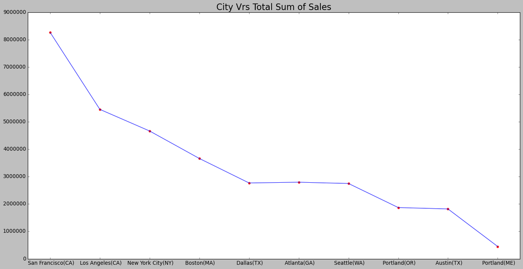

```python
names=stockData3BestCity['City']values=stockData3BestCity['Sales']plt.style.use('classic')plt.figure(figsize=(70,10))plt.subplot(131)##plt.bar(names, values, color='b')##plt.subplot(132)plt.title('City Vrs Total Sum of Sales',fontsize=20)plt.scatter(names,values,color='r')##plt.subplot(133)plt.plot(names,values)plt.show()
```

MatplotLib and SK Learn, another popular and most widely used Python Visualization and Modeling Machien Learning in Data Science. The Plot above shows the distribution of Total Sum of Sales in each Segment or City.

### Computing Sales and Quantity Sold By City and Month

```python
## Total Sum of sales in Quantity and sales by States in each Month from Jan to Dec.pd.set_option("display.max_rows",None,"display.max_columns",None)stockData3BestMonth=pd.DataFrame(stockData3.groupby(["City","Month"],as_index=False).sum())stockData3BestMonth.head()
```

|  | City | Month | QuantityOrdered | PriceEach | Sales |
| --- | --- | --- | --- | --- | --- |
| 0 | Atlanta(GA) | 1 | 876 | 148523.69 | 149159.54 |
| 1 | Atlanta(GA) | 10 | 1793 | 304508.46 | 306293.01 |
| 2 | Atlanta(GA) | 11 | 1568 | 273143.85 | 275338.70 |
| 3 | Atlanta(GA) | 12 | 2225 | 359097.06 | 360899.26 |
| 4 | Atlanta(GA) | 2 | 1042 | 175851.81 | 176470.30 |

```python
pd.set_option("display.max_rows",None,"display.max_columns",None)stockData3BestMonth=stockData3BestMonth.sort_values(["Sales","QuantityOrdered"],ascending=False)stockData3BestMonth.head()
```

|  | City | Month | QuantityOrdered | PriceEach | Sales |
| --- | --- | --- | --- | --- | --- |
| 99 | San Francisco(CA) | 12 | 6787 | 1100501.11 | 1106601.27 |
| 97 | San Francisco(CA) | 10 | 5310 | 861937.47 | 866700.98 |
| 102 | San Francisco(CA) | 4 | 4975 | 805693.57 | 812426.19 |
| 103 | San Francisco(CA) | 5 | 4443 | 772384.31 | 776679.49 |
| 98 | San Francisco(CA) | 11 | 4840 | 760902.41 | 764979.29 |

```python
pd.set_option("display.max_rows",None,"display.max_columns",None)stockData3BestMonth111=stockData3BestMonth.sort_values(["Month","Sales"],ascending=False)stockData3BestMonth111
```

|  | City | Month | QuantityOrdered | PriceEach | Sales |
| --- | --- | --- | --- | --- | --- |
| 107 | San Francisco(CA) | 9 | 3083 | 460938.06 | 463595.72 |
| 59 | Los Angeles(CA) | 9 | 2123 | 352525.82 | 354075.69 |
| 71 | New York City(NY) | 9 | 1708 | 298981.09 | 300563.83 |
| 35 | Boston(MA) | 9 | 1456 | 246591.73 | 248408.73 |
| 11 | Atlanta(GA) | 9 | 1035 | 169923.85 | 171278.89 |
| 47 | Dallas(TX) | 9 | 1053 | 163076.03 | 164212.86 |
| 119 | Seattle(WA) | 9 | 1059 | 155312.63 | 156369.27 |
| 23 | Austin(TX) | 9 | 763 | 105825.92 | 106483.70 |
| 95 | Portland(OR) | 9 | 668 | 103159.92 | 103811.88 |
| 83 | Portland(ME) | 9 | 161 | 28657.04 | 28759.56 |
| 106 | San Francisco(CA) | 8 | 3191 | 535065.50 | 538778.10 |
| 58 | Los Angeles(CA) | 8 | 2076 | 344302.64 | 345893.50 |
| 70 | New York City(NY) | 8 | 1809 | 301152.88 | 303183.46 |
| 34 | Boston(MA) | 8 | 1408 | 236932.64 | 239275.26 |
| 118 | Seattle(WA) | 8 | 1147 | 188466.05 | 189715.09 |
| 46 | Dallas(TX) | 8 | 1102 | 178958.29 | 179763.46 |
| 10 | Atlanta(GA) | 8 | 1053 | 168443.29 | 169267.66 |
| 22 | Austin(TX) | 8 | 735 | 125146.00 | 125713.61 |
| 94 | Portland(OR) | 8 | 745 | 116123.80 | 116881.14 |
| 82 | Portland(ME) | 8 | 182 | 35754.33 | 35996.60 |
| 105 | San Francisco(CA) | 7 | 3994 | 638095.00 | 642881.76 |
| 57 | Los Angeles(CA) | 7 | 2501 | 392183.65 | 394334.64 |
| 69 | New York City(NY) | 7 | 2168 | 353338.28 | 355716.10 |
| 33 | Boston(MA) | 7 | 1772 | 290151.72 | 291497.14 |
| 117 | Seattle(WA) | 7 | 1265 | 211415.90 | 212513.92 |
| 45 | Dallas(TX) | 7 | 1236 | 211201.99 | 212325.17 |
| 9 | Atlanta(GA) | 7 | 1259 | 210979.19 | 211766.47 |
| 21 | Austin(TX) | 7 | 850 | 149775.88 | 150324.93 |
| 93 | Portland(OR) | 7 | 809 | 143376.72 | 143994.49 |
| 81 | Portland(ME) | 7 | 218 | 32021.23 | 32421.14 |

[output cut: 90 more lines]

Sales made by each City is vital in this Analysis, It gave us full adea of how much each City contributed to total sales per Month. The summury is very usefull in identifying how much revenue was returned from all monthly purchasese. The Analysis also creat a window for Maximization and planning both short and long term Forcasting. In the Management of finance on Budgeting which is a keey financial plan of business attempting to forcast a number of months ahead, it is very important to know how much in each month, each City responded to our products and the revenue we made in each month by each City or Market segment. From our Analysis, in the month of January, customers at San Francisco(CA) made the highest purchase of 2661 and a total sum amount of $ 435588.33, followed by Los Angeles (CA) with a purchases of 1716 Items and a total sum amount of $ 288601.90. Boston(MA) also contributed 1174 of tottal items sold and a total sum amount of $ 201088.49 and Atlanta(GA),876 Items and a total sum amount $ 149159.54. Again, Seattle(WA) also purchased 810 Items and contributed to $ 140692.05 of total sales made in January 2019, the City of Portland(OR) purchased 555 Items anda total sum amount $ 92276.76. Austin(TX) and Portland(ME) with 582 and 138 Items contributiing to 88087.06 and 22708.80 respectively.

In the Month of February San Francisco(CA) with the highest purchases of 3243 Items contributing sum amount of $ 547072.34, Los Angeles(CA) being the second higest of 2160 Items and sum amount of $ 342061.66, followed by New York City(NY) with 1805 Items and sum amount of $ 305372.26, Boston(MA) third of competotive order of 1400 Items and also contributing $ 214808.36 and Dallas(TX) with 1112 Item and a total sum of sales $ 186667.99. Again, Atlanta(GA) petronised most of our products with an order of 1042 items and contributed to $ 176470.30 of our Total sum of sales whilst Seattle(WA) was next on competitive order of 1066 Items and sum of sales of $ 171330.25. Portland(OR) also compete with 728 Items and sum of sales of $ 119606.37. Last, Austin(TX) and Portland(ME) with quatity order of Items of 685 and 208, sum of sales of $ 108787.40 and $ 29845.49 respectively.

In the Month of March, 2019, San Francisco(CA) still toped in ranking order of purchases of 4025 Items and sum of sales of $ 693726.96, Los Angeles(CA) with 2755 order of purchases and sum of sales of $ 429929.37, followed by New York City(NY) with 2211 Items of order and sum of Sales of $ 367262.20, Boston(MA) also was on the log with 1881 order of Items and sum of sales of $ 301023.81. Atlanta(GA) with 1384 Items anad sales of $ 231905.38 whilst Dallas(TX) made a total purcgase of 1349 items and Sales returns of $ 222376.68. Seattle(WA) with 1331 Items of order and sum of $ 219118.70. Portland(OR),with 903 Items and contributed 156691.72 of our total sales in march. Last, Austin(TX) with 952 order of items and sales returns of $ 154549.27 and Portland(ME) 214 Items and sales of $ 30516.29.

In April, 2019, San Francisco(CA) again leading of order of Items of 4975 and $ 812426.19 of sales, Los Angeles(CA) with 3398 Items and $ 550264.02 of Sales, New York City(NY) also with 2746 items and Sales of $ 449447.75. Boston(MA) 2189 Items and sum of Sales of $ 353807.11, Atlanta(GA) also made a total order of 1634 Items contributing to $ 284448.91 of our total sales in April. Customers in Seattle(WA) with 1609 items and $ 276254.07, Dallas(TX) also on the order with 1518 Items and $ 251360.48 of sales. Portland(OR) with 1132 Items and $ 197441.63 of sales returns whilst Austin(TX) was next of the log with 1092 Items and $ 172683.59 of sum of sales and Portland(ME) with the least orders of 265 Items and $ 42536.49 of total sales.

In June 2019, San Francisco(CA) contributed the highst order 3687 Items and $613173.48, Los Angeles(CA) was the second highest with an order of 2452 Items and $ 451531.93 or sum of sales of order, New York City(NY) with 1999 Items and sum of sales of $ 324148.58, Boston(MA) next with 1614 items quantity order and $ 254747.89 of sum of sales. Atlanta(GA) also contributed heavily on quatity border of purchases of 1231 Items summing up to $ 219816.47 of Sales, Seattle(WA) with 1198 Items of quantity order and a sum of sales of $ 213853.52, whilst Dallas(TX) also made a total purchase of 1188 Items and $ 186885.75 of sum of Sales. Moreover, Austin(TX) with 803 items and $ 144057.29 of sales, Portland(OR) with quatity order of 850 items and $ 139562.02 of Sales and Portland(ME) last on the log order with 231 Items and $ 30025.33 of sum of sales in June only.

Our Analysis shows that in July, 2019, San Francisco(CA) with a quantity order of 3994 Items and $ 642881.76 of sales, Los Angeles(CA) again as second highest with 2501 quatity order and $ 394334.64 of sales, New York City(NY) with 2168 Items on order summing up to $ 355716.10 of sales, Boston(MA) follows with 1772 items on order and $ 291497.14 on sales. Seattle(WA) with 1265 on orders and $ 212513.92 on sales, Dallas(TX) also with 1236 on quatity order and $ 212325.17 on sum of Sales, Atlanta(GA) with 1259 Items on purchase and $ 211766.47 on sum of sales, Austin(TX) making a total order of 850 Items and $ 150324.93 as sum of sales on quatity order. Last, Portland(OR) with 809 items on order and $ 143994.49 as sum of sales and Portland(ME) with 218 items and $ 32421.14 as sum of sales on July only.

In the Month of August, San Francisco(CA) still leading in total purchase with 3191 of quatity order and $ 538778.10 of sum of sales, Los Angeles(CA) stiil second highset in oreder quatity of 2076 items and $ 345893.50 of sales, New York City(NY) with 1809 quatity order and $ 303183.46 of sales, Boston(MA) also with 1408 items on order and $ 239275.26 as sum of sales. Seattle(WA) made a total order 1147 items and $ 189715.09 as sum of sales, Dallas(TX) with 1102 Items and sum of sales of $ 179763.46, Atlanta(GA) with 1053 Items and $ 169267.66 of sales, Austin(TX) with 735 Items and $ 125713.61 of total sales. Portland(OR) with 745 qauntity of order and $ 116881.14 of sum of sales and last, Portland(ME) with 182 of quantity order of items and a sum of sales of $ 35996.60 for ther month of August only.

The distrubition table again shows that in the month of September 2019, San Francisco(CA) as usual leading on quatity of order with 3083 Items and $ 463595.72 as sum of sales, followed by Los Angeles(CA) with 2123 items of order and $ 354075.69 as sales returns on order, New York City(NY) also with quantity order of 1708 Items and $ 300563.83 as sum of sales of order. Boston(MA) made a total quantity order of 1456 items and $ 248408.73 as sales, Atlanta(GA) with 1035 Itmes and a sum of sales of $ 171278.89, Dallas(TX) as one of our competitive market segments also with 1053 of total orders and a sum of sales on order of $ 164212.86. Again, Seattle(WA) also with 1059 iteme on order and $ 156369.27 of sum of sales and Austin(TX) with 763 items and a sales of $ 106483.70. Last, Portland(OR) and Portland(ME) with order quntity of 668 and 161, sum of sales of $ 103811.88 and $ 28759.56 respectively for the monthe of September only.

In November, San Francisco(CA) with the highest purchases of 4840 Items contributing sum amount of $ 764979.29, Los Angeles(CA) being the second higest of 3120 Items and sum amount of $ 499690.79, followed by New York City(NY) with 2651 Items and sum amount of $ 428180.32, Boston(MA) third of competotive order of 2173 Items and also contributing $ 351546.02 and Atlanta(GA) with 1568 Item and a total sum of sales $ 275338.70. Again, Seattle(WA) petronised most of our products with an order of 1583 items and contributed to $ 252080.13 of our Total sum of sales whilst Dallas(TX) was next on competitive order of 1562 Items and sum of sales of $ 248609.56. Portland(OR) also compete with 1065 Items and sum of sales of $ 173,210.70. Last, Austin(TX) and Portland(ME) with quatity order of Items of 977 and 259, sum of sales of $ 1712,86.47 and $ 34,681.22 respectively.

In December, this is the moth that shows our booming market share more than other moth in the year of 2019 comparing all quantity of order and sum of sales by each City. The distrubition table again shows that in the month of December 2019, San Francisco(CA) as usual leading on quatity of order with 6787 Items and $ 1,106,601.27 as sum of sales, followed by Los Angeles(CA) with 4378 items of order and $ 684,044.84 as sales returns on order, New York City(NY) also with quantity order of 3816 Items and $ 646,770.83 as sum of sales of order. Boston(MA) made a total quantity order of 3026 items and $ 509,599.16 as sales, Seattle(WA) with 2203 Itmes and a sum of sales of $ 387,317.93, Dallas(TX) as one of our competitive market segments also with 2303 of total orders and a sum of sales on order of $ 380,718.85. Again, Atlanta(GA) also with 2225 iteme on order and $ 360,899.26 of sum of sales and Portland(OR) with 1506 items and a sales of $ 251,748.04. Last, Austin(TX) and Portland(ME) with order quntity of 1518 and 352, sum of sales of $ 233,777.09 and $ 51,966.07 respectively for the monthe of December only.

```python
stockData3BestMonth111.shape
```

```
(120, 5)
```

### Analysing and Comparing Sales In Each Month

```python
fig=px.bar(stockData3BestMonth,x="City",y="Sales",title='Total Sales In Each Months By State',color="Month",width=1000,height=700,hover_data=['QuantityOrdered','PriceEach'])#fig.update_traces(texttemplate='%{text:.2s}')##fig.update_layout(uniformtext_minsize=8, uniformtext_mode='hide')fig.show()#with open("figure6.pdf", "wb") as f:# f.write(scope.transform(fig, format="pdf"))#fig.write_html("file6.html")
```

[interactive chart not shown]

A "Stacked Bar plot" with an interactive Plotly Library in Python to Visualized our distribution of total Sales anad quantity order by each City and each month. From a statistics point of view and a mere observation December was our booming market and sales retunrs and this could be a factor of Christmas which likely, every producer is likely to earn more income. Top manager can use this period a source of comperitive advantage so as to target customers of specific months and its effects on our products ad service so as to creat, gain and maintain competitive advantage by creating a unique and a core resiources and compitencies in the form of promotions and advertisments.

```python
## Scatter Plot Of Sum of Sales in every month by every City, This plot show all sum of order and Each price of a sale and Sum of sales in all 12 month fig=px.scatter(stockData3BestMonth,x="City",y="Sales",size="Sales",color="Month",title='Total Sales In Each Months By State',hover_data=['QuantityOrdered','PriceEach'],size_max=40,)fig.update_traces(texttemplate='%{text:.2s}')##fig.update_layout(uniformtext_minsize=8, uniformtext_mode='hide')fig.show()#with open("figure5.pdf", "wb") as f:# f.write(scope.transform(fig, format="pdf"))fig.write_html("file5.png")
```

[interactive chart not shown]

A bubble plot with an interactive Plotly Library in Python to Visualized our distribution of total Sales anad quantity order by each City and each month. From a statistics point of view and a mere observation December was our booming market and sales retunrs and this could be a factor of Christmas which likely, every producer is likely to earn more income. Top manager can use this period a source of comperitive advantage so as to target customers of specific months and its effects on our products ad service so as to creat, gain and maintain competitive advantage by creating a unique and a core resiources and compitencies in the form of promotions and advertisments.

```python
x=stockData3BestMonth['Month']y=stockData3BestMonth['Sales']z=np.random.rand(40)colors=np.random.rand(40)
```

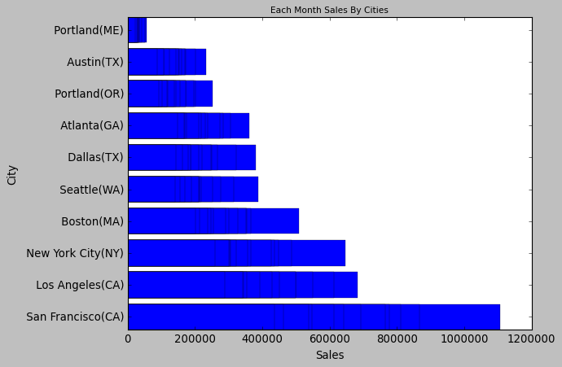

```python
data=('stockData3BestMonth')group_data=stockData3BestMonth['Sales']group_names=stockData3BestMonth['City']#group_mean = np.mean(group_data)fig,ax=plt.subplots()plt.style.use('seaborn-paper')labels=ax.get_xticklabels()ax.set(xlabel='Sales',ylabel='City',title='Each Month Sales By Cities')plt.figure(figsize=(90,20))ax.barh(group_names,group_data)
```

```python
## Top sales Made in all month from the highiest to the lowerst ##stockData3BestMonthsort = stockData3BestMonth.sort_values(["QuantityOrdered"], ascending = False)##stockData3BestMonthsort.head(10)
```

### Analysing Total, Average, Maximum and Minimum Sales By Cities In Each Month

```python
## Grouping All state and Mounth How much they purchase ou product by every monthpd.set_option("display.max_rows",None,"display.max_columns",None)stockDataAllMonthGropued=stockData3.groupby(['City','Month'],as_index=True).agg({'Sales':['sum','mean','max','min']}).round(2)stockDataAllMonthGropued
```

| City | Month | Sales sum | Sales mean | Sales max | Sales min |
| --- | --- | --- | --- | --- | --- |
| Atlanta(GA) | 1 | 149159.54 | 190.01 | 1700.00 | 2.99 |
|  | 10 | 306293.01 | 191.19 | 1700.00 | 2.99 |
|  | 11 | 275338.70 | 194.72 | 1700.00 | 2.99 |
|  | 12 | 360899.26 | 181.45 | 1700.00 | 2.99 |
|  | 2 | 176470.30 | 188.54 | 1700.00 | 2.99 |
|  | 3 | 231905.38 | 186.27 | 1700.00 | 2.99 |
|  | 4 | 284448.91 | 193.24 | 1700.00 | 2.99 |
|  | 5 | 238853.99 | 179.72 | 1700.00 | 2.99 |
|  | 6 | 219816.47 | 198.57 | 1700.00 | 2.99 |
|  | 7 | 211766.47 | 184.79 | 1700.00 | 2.99 |
|  | 8 | 169267.66 | 179.88 | 1700.00 | 2.99 |
|  | 9 | 171278.89 | 187.19 | 1700.00 | 2.99 |
| Austin(TX) | 1 | 88087.06 | 166.52 | 1700.00 | 2.99 |
|  | 10 | 203196.12 | 186.08 | 1700.00 | 2.99 |
|  | 11 | 171286.47 | 197.11 | 1700.00 | 2.99 |
|  | 12 | 233777.09 | 173.43 | 1700.00 | 2.99 |
|  | 2 | 108787.40 | 174.06 | 1700.00 | 2.99 |
|  | 3 | 154549.27 | 183.77 | 1700.00 | 2.99 |
|  | 4 | 172683.59 | 177.48 | 1700.00 | 2.99 |
|  | 5 | 160635.22 | 191.69 | 1700.00 | 2.99 |
|  | 6 | 144057.29 | 201.48 | 1700.00 | 2.99 |
|  | 7 | 150324.93 | 197.02 | 1700.00 | 2.99 |
|  | 8 | 125713.61 | 193.70 | 1700.00 | 2.99 |
|  | 9 | 106483.70 | 160.61 | 1700.00 | 2.99 |
| Boston(MA) | 1 | 201088.49 | 191.33 | 1700.00 | 2.99 |
|  | 10 | 367036.39 | 168.75 | 1999.98 | 2.99 |
|  | 11 | 351546.02 | 183.19 | 1700.00 | 2.99 |
|  | 12 | 509599.16 | 189.09 | 1700.00 | 2.99 |
|  | 2 | 214808.36 | 171.16 | 1700.00 | 2.99 |
|  | 3 | 301023.81 | 182.99 | 1700.00 | 2.99 |

[output cut: 90 more lines]

```python
stockDataAllMonthGropuedSave=pd.DataFrame(stockDataAllMonthGropued)stockDataAllMonthGropuedSave
```

| City | Month | Sales sum | Sales mean | Sales max | Sales min |
| --- | --- | --- | --- | --- | --- |
| Atlanta(GA) | 1 | 149159.54 | 190.01 | 1700.00 | 2.99 |
|  | 10 | 306293.01 | 191.19 | 1700.00 | 2.99 |
|  | 11 | 275338.70 | 194.72 | 1700.00 | 2.99 |
|  | 12 | 360899.26 | 181.45 | 1700.00 | 2.99 |
|  | 2 | 176470.30 | 188.54 | 1700.00 | 2.99 |
|  | 3 | 231905.38 | 186.27 | 1700.00 | 2.99 |
|  | 4 | 284448.91 | 193.24 | 1700.00 | 2.99 |
|  | 5 | 238853.99 | 179.72 | 1700.00 | 2.99 |
|  | 6 | 219816.47 | 198.57 | 1700.00 | 2.99 |
|  | 7 | 211766.47 | 184.79 | 1700.00 | 2.99 |
|  | 8 | 169267.66 | 179.88 | 1700.00 | 2.99 |
|  | 9 | 171278.89 | 187.19 | 1700.00 | 2.99 |
| Austin(TX) | 1 | 88087.06 | 166.52 | 1700.00 | 2.99 |
|  | 10 | 203196.12 | 186.08 | 1700.00 | 2.99 |
|  | 11 | 171286.47 | 197.11 | 1700.00 | 2.99 |
|  | 12 | 233777.09 | 173.43 | 1700.00 | 2.99 |
|  | 2 | 108787.40 | 174.06 | 1700.00 | 2.99 |
|  | 3 | 154549.27 | 183.77 | 1700.00 | 2.99 |
|  | 4 | 172683.59 | 177.48 | 1700.00 | 2.99 |
|  | 5 | 160635.22 | 191.69 | 1700.00 | 2.99 |
|  | 6 | 144057.29 | 201.48 | 1700.00 | 2.99 |
|  | 7 | 150324.93 | 197.02 | 1700.00 | 2.99 |
|  | 8 | 125713.61 | 193.70 | 1700.00 | 2.99 |
|  | 9 | 106483.70 | 160.61 | 1700.00 | 2.99 |
| Boston(MA) | 1 | 201088.49 | 191.33 | 1700.00 | 2.99 |
|  | 10 | 367036.39 | 168.75 | 1999.98 | 2.99 |
|  | 11 | 351546.02 | 183.19 | 1700.00 | 2.99 |
|  | 12 | 509599.16 | 189.09 | 1700.00 | 2.99 |
|  | 2 | 214808.36 | 171.16 | 1700.00 | 2.99 |
|  | 3 | 301023.81 | 182.99 | 1700.00 | 2.99 |

[output cut: 90 more lines]

```python
## stockDataAllMonthGropuedSave.to_csv('stockDataAllMonthGropuedSave3.csv')
```